# Mutation Enrichment Analysis on Interface Residues

### Summary of the results

Below two analyses are carried out

1. A global mutation enrichment analysis
   - Here we determine whether mutated residues are enriched at interface residues for all the provided proteins
   - The analysis is performed using potential cancer-driver missense mutations
   - Below the percentage of residues inside and outside the interface that are hit by at least one missense mutation are plotted. The hypergeometric test is used to determine the enrichment of mutated residues
   - Only the proteins with at least one mutation in their entire sequence are considered
1. A protein specific mutation enrichment analysis
   - Here we determine the enrichment of mutations for each protein individually
   - The analysis is performed using potential cancer-driver missense mutations
   - Below the FDR adjusted enrichment p-values are plotted for each protein. The enrichment p-values were obtained using the binomial test. Multiple testing correction was performed with the Benjamini/Hochberg algorithm. A false discovery rate of 0.05 was used.
   - Only the proteins with a significant enrichment are plotted

```python
import pandas as pd
import numpy as np
import mutation_enrichment as mut
```

## Global mutated residues enrichment analysis

```python
df_driver = pd.read_csv(snakemake.input[0], sep = '\t')

df_driver = df_driver.loc[(df_driver['mut_in_interface'] > 0) | (df_driver['mut_not_in_interface'] > 0)]
```

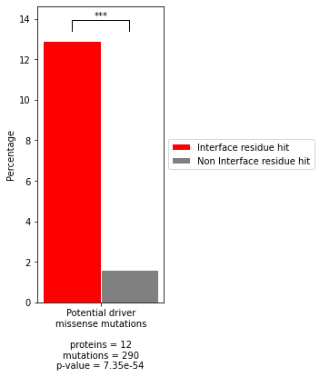

```python
dfs = [df_driver]
cols = ['mut_in_interface', 'mut_not_in_interface', 'interface_len', 'outside_len']
labels = ['Potential driver\nmissense mutations\n']
legend = ['Interface residue hit', 'Non Interface residue hit']

hypergeom_results = mut.enrichment_analysis(dfs, cols, repetition = False)
mut.percent_bar(dfs, cols, labels, hypergeom_results, legend, verbose_labels=True, figure_size = (2.5, 6), save_path = snakemake.output[0])
```

**Interpretation**

If the interface residues found are important in cancer we expect a significant enrichment of residues at the interface that are hit by cancer driver missense mutations.

## Protein specific mutation enrichment analysis

```python
df_driver = pd.read_csv(snakemake.input[1], sep = '\t')

df_driver = df_driver.loc[(df_driver['mut_in_interface'] > 0) | (df_driver['mut_not_in_interface'] > 0)]
df_driver = df_driver.loc[df_driver['reject_null_hypothesis'] == True]
```

### Proteins enriched for potential driver missense mutations within the interface residues

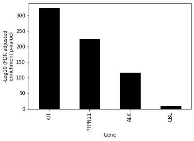

```python
df_driver['-Log10 (FDR adjusted\nenrichment p-value)'] = -np.log10(df_driver['adjusted_enrichment_pval'])
mut.enrichment_bar(df_driver, 'Gene_name', '-Log10 (FDR adjusted\nenrichment p-value)', save_path = snakemake.output[1])
```

**Interpretation**

Similar to the analysis above if the mutation of interface residues is important in cancer we expect a significant enrichment of potential driver missense mutations at the interface. Here we are able to see for exactly what proteins there is a significant enrichment.